# (Loan Analysis using Prosper Loan Data)

## Preliminary Wrangling

> This data set contains 113,937 loans with 81 variables on each loan, including loan amount, borrower rate (or interest rate), current loan status, borrower income, and many others.

> This data dictionary explains the variables in the data set. You are not expected to explore all of the variables in the dataset! Focus your exploration on about 10-15 of them.

We can see pattern of Nulls' counts here!

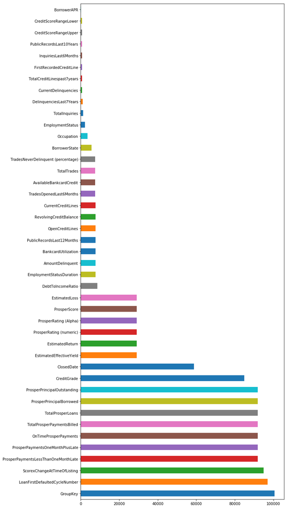

```python
Nulls.plot(kind='barh', figsize=(10, 25))
```

## Univariate Exploration

> In this section, investigate distributions of individual variables. If you see unusual points or outliers, take a deeper look to clean things up and prepare yourself to look at relationships between variables.

## Number of Loans Due to Income Rate

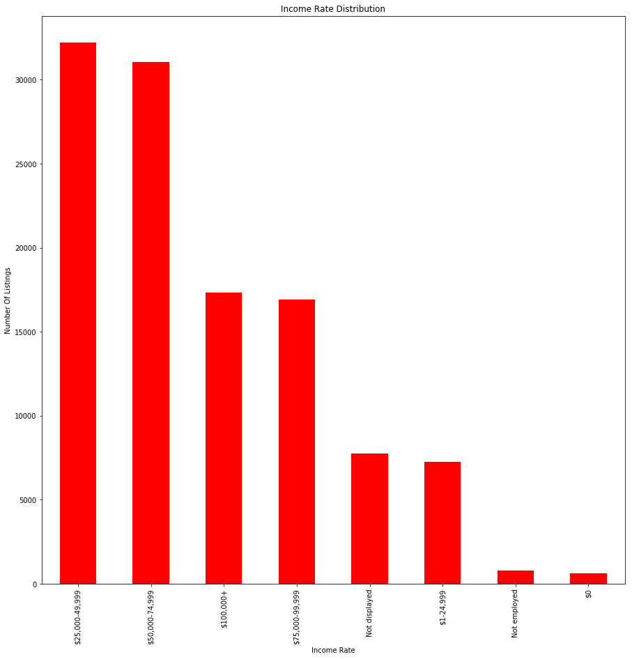

```python
#Bar Graph for each income range specified

plt.figure(figsize=(10, 5))
loan_df.IncomeRange.value_counts().plot(kind='bar', color='red', figsize=(15,15));

plt.title('Income Rate Distribution');
plt.xlabel('Income Rate');
plt.ylabel('Number Of Listings');

plt.xticks();
```

## Top 10 Occupations in Loans

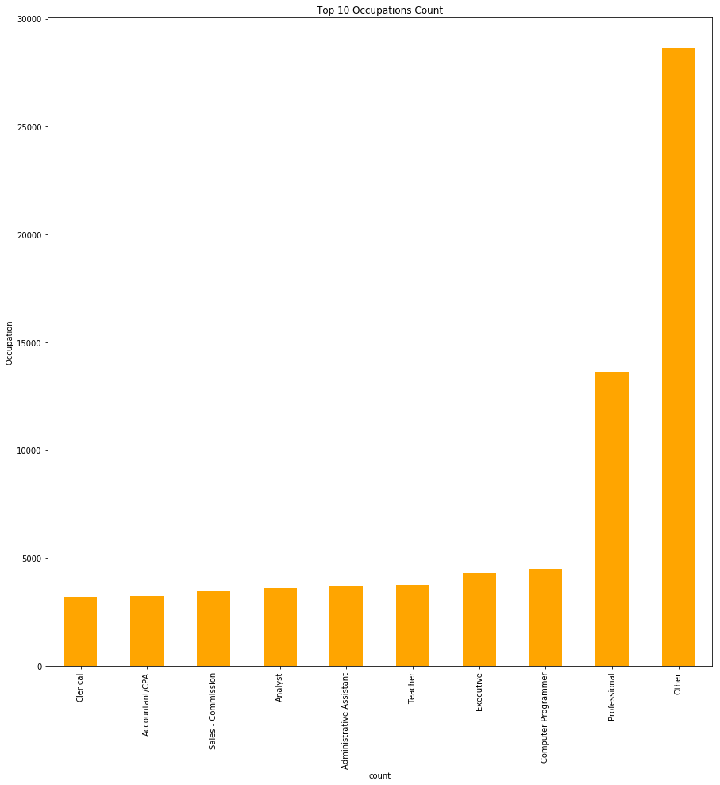

```python
# see the top 10 occupations of borrowers in ascending order
loan_df['Occupation'].value_counts()[9::-1].plot(kind='bar', rot=90, color='orange', figsize=(15, 15))
plt.title('Top 10 Occupations Count')
plt.xlabel('count')
plt.ylabel('Occupation')
plt.fontsize = 12
```

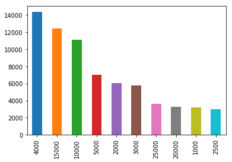

```python
loan_df['LoanOriginalAmount'].value_counts()[:10].plot(kind='bar')
```

## Bivariate Exploration

> In this section, investigate relationships between pairs of variables in your data. Make sure the variables that you cover here have been introduced in some fashion in the previous section (univariate exploration).

## Yearly Borrower Rates

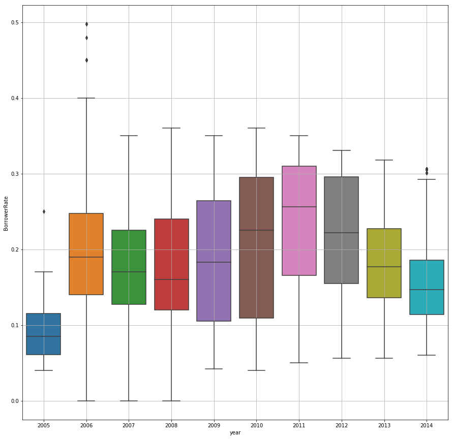

```python
plt.figure(figsize=(15,15))
sb.boxplot(data = loan_df , x = 'year' , y='BorrowerRate')
plt.grid()
```